# 误差的反向传播

### 1. 误差引导的学习过程

让我们回忆一下上节课上学习“分辨虫虫”的例子吧！

我们为了让计算机学习画定一条完美的直线来将毛虫与瓢虫区分开，做了哪些事情呢？

首先，我们先猜测一个斜率A，这个斜率A就是我们要调节的**参数**。我们将所需值与这个参数下的真实值进行比较，计算出**误差**。

接下来，我们利用**误差**来调节**参数**,使得真实值越来越接近所需值。

重复以上过程，直到能得到令人满意的结果。

总结一下，学习过程可以简化为2步：

```
 1.计算误差
 2.利用误差来更新参数
```

下面我们将用两节课的时间来完成这2步：

```
 1.计算误差——误差的反向传播
 2.利用误差来更新参数——梯度下降法
```

那么对于一个神经网络，什么是需要调节的参数呢？我们已经学过了，其实需要调节的参数就是**链接权重矩阵**。为此，我们也可以先设定一个初始的权重矩阵，然后再利用误差对其进行改进。

而我们所掌握的误差在于哪里呢？在于这个神经网络的最终输出值与训练样本的差异。

而这个误差是多个神经元经过多条链接所共同作用的结果。如果我们利用所有的误差值，而只对其中一个权重进行更新，那么这将毫无意义。因为忽略了其他的神经元以及其他各条链接。

于是，我们需要想个办法，将神经网络的最终输出误差分配到各个节点上去。

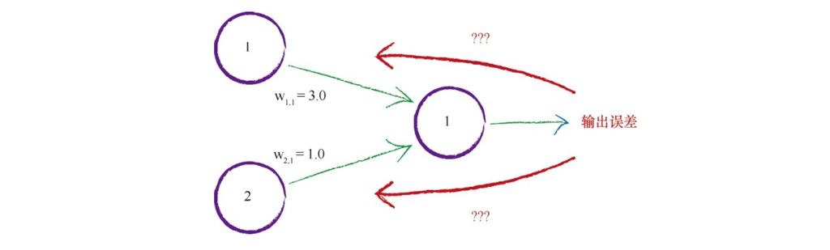

那么该如何分配误差呢？

有这样两种思想：一种是等分误差。另一种是不等分误差。

你认为哪一种分配方法更加合适呢？

请你选择你认为更合适的分配误差的方法，并说明理由。

```python
#请你选择你认为更合适的分配误差的方法，并说明理由。

#我认同 ：

#原因是 ：
```

### 2. 误差的反向传播

事实上，在分配误差的时候，我们采用的是按照链接权重的比例来分割。原因是上一层的2个节点是以权重比例来对下一层的结果起作用的，于是它们理应为下一层的误差“承担相应的责任”。

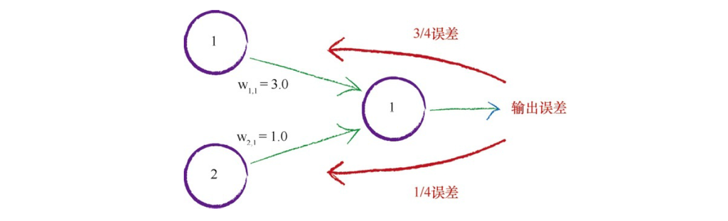

换句话说，我们需要用这个误差的3/4，来调整 w(1,1); 用这个误差的1/4，来调整w（2,1）

迄今为止，我们在两件事情上使用了链接权重。

1.我们使用权重，将**信号**从输入层**向前**传播到输出层。 2.我们使用权重，将**误差**从输出层**向后**传播到网络中。我们称这种方法为**误差的反向传播**。

如果有多个节点，那么我们将对每一个节点执行误差分割操作。

如果有多个层，那么我们将从输出层向后，一层一层地执行误差分割工作。

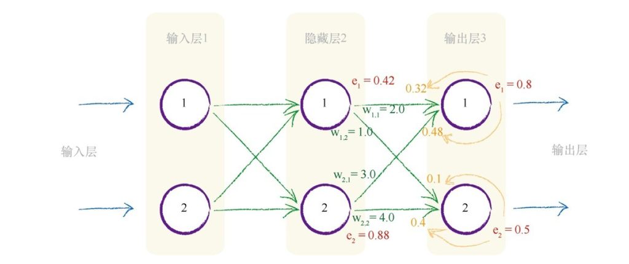

在上图中，我们直接已知的是来自每个输出层节点的误差:

输出层第一个节点的误差e(output,1) = 所期望的输出值t1 - 实际的输出值o1

输出层第二个节点的误差e(output,2) = 所期望的输出值t2 - 实际的输出值o2

那么对于输出层的第一个节点，它的误差$e_{output,1}$可以按照权重w（1,1）和 w（2,1），分配到隐藏层的2个神经元中，就像这样：

隐藏层的第一个节点得到：

$$ e_{output,1} * \dfrac{w_{1,1}}{w_{1,1}+w_{2,1}}$$

隐藏层的第二个节点得到：

$$e_{output,1} * \dfrac{w_{2,1}}{w_{1,1}+ w_{2,1}}$$

而对于输出层的第二个节点，它的误差$e_{output,2}$可以按照权重w（1,2）和 w（2,2），分配到隐藏层的2个神经元中，就像这样：

隐藏层的第一个节点得到：

$$e_{output,2} * \dfrac{w_{1,2}}{w_{1,2}+w_{2,2}}$$

隐藏层的第二个节点得到：

$$ e_{output,2} * \dfrac{w_{2,2}}{w_{1,2}+ w_{2,2}}$$

那么隐藏层的第一个节点一共得到多少误差呢？

$$ e_{hidden,1} = 链接w_{1,1}上分割来的输出层第一个节点的误差 + 链接w_{1,2}上分割来的输出层第二个节点的误差 $$

$$ e_{hidden,1} = e_{output,1} * \dfrac{w_{1,1}}{w_{1,1}+w_{2,1}} + e_{output,2} * \dfrac{w_{1,2}}{w_{1,2}+w_{2,2}} $$

$$ e_{hidden,1} = 0.8 * \dfrac{2.0}{2.0 + 3.0} + 0.5 * \dfrac{1.0}{1.0 + 4.0} = 0.42 $$

$$ e_{hidden,1} = 0.42 $$

于是，我们可以如法炮制，得到：

1.隐藏层第二个节点的误差

2.输入层第一个节点的误差

3.输入层第二个节点的误差

#### 别懒，自己算一遍！！！

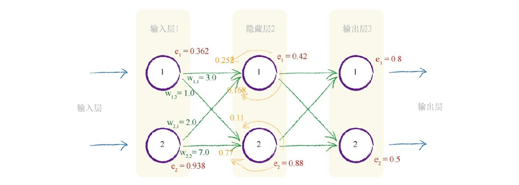

### 3. 使用矩阵乘法进行反向传播误差

之前我们学过了矩阵乘法，相信大家都很喜欢矩阵乘法的简单、实用、可靠的朋友。

它既然可以帮助我们计算神经网络中向前传播的信号，是不是也能帮我们计算反向传播的误差呢？

答案是肯定的。

我们用下面的矩阵来表示输出层的误差：

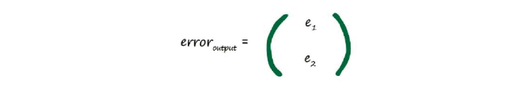

接下来，我们要写出隐藏层的误差矩阵：

是不是看上去很简单？**请你自己验算一遍！**

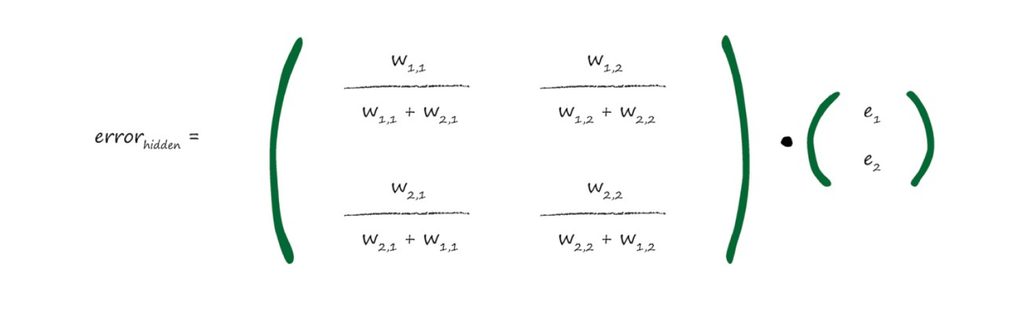

**然而，它还可以更简单！**

我们看一下左边的权重矩阵。它的分子很简单，而分母看上去很复杂。

事实上，它的分母是一种“归一化因子”，意思是让这几个分子加和为1，让它们互相能说上话。

如果，我们之前使用某种特定的方法，保证了这几个分子能说上话。那就不妨大胆一点，把分母给省掉。

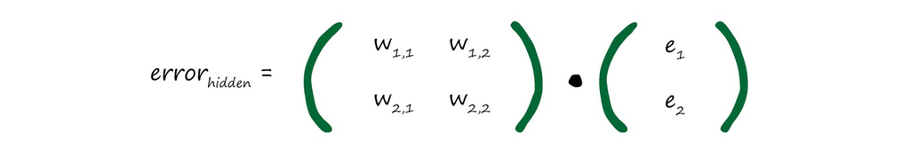

这个矩阵简直太简单了有木有？赏心悦目。

我们再来欣赏一下。

以隐藏层的第一个节点的第一项为例，我们使用简单得多的e1 *w1,1 来代替e1* w1,1 / ( w1,1 + w2,1 )。

它失去了什么呢？失去的是这个误差的绝对大小。然而相对大小并没有改变。

而我们的终极目的并不是要求出每一层每一个节点的绝对误差，而是根据误差的相对大小来调整链接权重。

于是，就这样吧。

还记得这个矩阵吗？

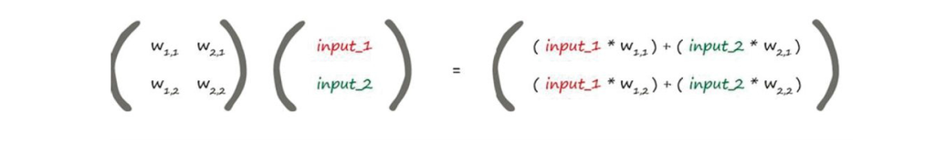

这是我们之前学过的神经网络用来向前传递信号的矩阵乘法形式。

它们是不是长得特别像？

只不过，那个权重矩阵的横竖颠倒了一下。

我们把矩阵的横竖颠倒称之为**转置**，用右上角的字母**T**来表示。

就像这样：

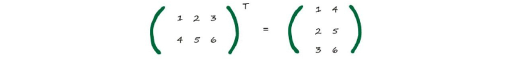

于是，我们就可以把反向传播误差的过程来表示成矩阵乘法啦：

$$error_{hidden} = W_{hidden}^{T} * error_{output}$$

超级简单啊！

```python
#现在我们把第2节中的例子用python实现一遍吧！
import numpy as np
import scipy.special

#输出层的误差矩阵output_errors：
output_errors = np.array([[0.8],[0.5]])

#隐藏层到输出层的链接矩阵W_hidden_output：
W_hidden_output = np.array([[2,3],[1,4]])

#将其转置
W_hidden_output_T = np.transpose(W_hidden_output)

#计算隐藏层的误差矩阵 = 转置矩阵W_hidden_output 点乘 矩阵I
hidden_errors = np.dot(W_hidden_output_T,output_errors)

#输出结果
print("隐藏层的误差矩阵为")
print(hidden_errors)
```

[output not shown]

```python
###下面是练习练习练习！
import numpy as np
import scipy.special

#隐藏层的误差矩阵hidden_errors：


#输入层到隐藏层的链接矩阵W_input_hidden：


#将其转置


#计算隐藏层的误差矩阵 = 转置矩阵W_input_hidden 点乘 矩阵I


#输出结果
```

## 本讲要点

1. 误差就是训练数据所给出的正确答案和实际输出之间的差值。
2. 误差的重要性在于知道神经网络通过调整链接权重进行学习。
3. 在计算中，我们需要把误差分配到每一节点中。分配的方法是按照链接权重的比例来分割下一层的误差，以此递归。输出层的误差就直接等于所需值与实际值之间的差值。
4. 反向传播误差可以表示为矩阵乘法。